# CRAN growth

In the past 3 months, 528 new packages were added to the CRAN package repository. 142 packages were unarchived, 274 were archived and 0 had to be removed. The following shows the growth of the number of active packages in the CRAN package repository:

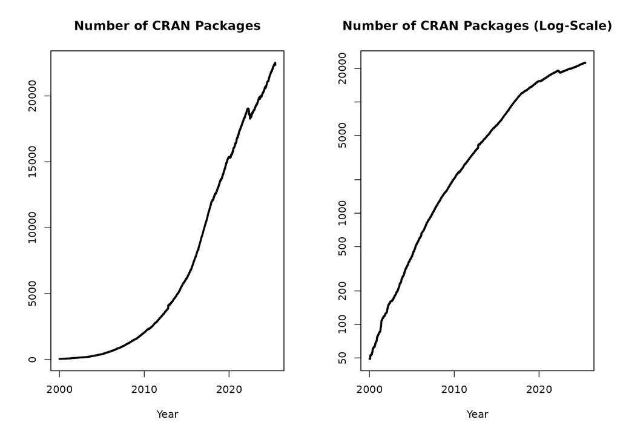

On 2025-03-31, the number of active packages was around 22253.

# CRAN package submissions

From January 2025 to March 2025 CRAN received 7690 package submissions. For these, 12213 actions took place of which 9271 (76%) were auto processed actions and 2942 (24%) manual actions.

Minus some special cases, a summary of the auto-processed and manually triggered actions follows:

|  | archive | inspect | newbies | pending | pretest | publish | recheck | waiting |
| --- | --- | --- | --- | --- | --- | --- | --- | --- |
| auto | 2798 | 623 | 1622 | 152 | 0 | 2401 | 931 | 356 |
| manual | 1171 | 4 | 13 | 6 | 60 | 1307 | 276 | 98 |

These include the final decisions for the submissions which were

|  | archive | publish |
| --- | --- | --- |
| auto | 2672 (35.5%) | 2179 (28.9%) |
| manual | 1157 (15.4%) | 1522 (20.2%) |

where we only count those as *auto* processed whose publication or rejection happened automatically in all steps.

# CRAN mirror security

Currently, there are 93 official CRAN mirrors, 77 of which provide both secure downloads via ‘`https`’ *and* use secure mirroring from the CRAN master (via rsync through ssh tunnels). Since the R 3.4.0 release, `chooseCRANmirror()` offers these mirrors in preference to the others which are not fully secured (yet).

# CRAN Task View Initiative

There are two new task views:

- [Compositional Data Analysis](https://CRAN.R-project.org/view=CompositionalData): Maintained by Karel Hron, Javier Palarea-Albaladejo, Matthias Templ, Alessandra Menafoglio.
- [Network Analysis](https://CRAN.R-project.org/view=NetworkAnalysis): Maintained by Fabio Ashtar Telarico, Pavel N. Krivitsky, James Hollway.

Currently there are 48 task views (see https://CRAN.R-project.org/web/views/), with median and mean numbers of CRAN packages covered 108 and 122, respectively. Overall, these task views cover 4906 CRAN packages, which is about 22% of all active CRAN packages.